# Mapa Mimulus - Passo3

Cristiane Taniguti, Fernando Correr, Fernando Espolador, Johnathan Pedroso

Maio de 2017

Aqui usaremos as informações dos grupos já montados nos passos anteriores e tentaremos encaixar os marcadores com desvios na segregação, os quais foram separados no primeiro passo. Para mais informações acesse a [página principal](https://cristianetaniguti.github.io/htmls/mapa_mimulus/mapa_mimulus.html)).

# 1 Carregando os dados

```r
library(onemap)
data1 <- read_mapmaker(file = "data_with_head.raw")
data_seg2 <- read_mapmaker(file = "data_with_distorted_2.raw")
ref <- read.csv(file = "LG.csv", stringsAsFactors = FALSE)


data <- combine_onemap(data1, data_seg2)

LOD1 <- suggest_lod(data)

rf2points1 <- rf_2pts(data, LOD = LOD1, max.rf = 0.5)

seg <- c(357:418)
```

A função ‘combine_onemap’ concatena os conjuntos de dados de forma que os últimos marcadores do arquivo serão todos pertencentes ao segundo arquivo, ou seja, os marcadores com desvio na segregação esperada. Utilizamos esse função ao invés do arquivo original ‘m_feb06.raw’ principalmente pela vantagem de inserir outros marcadores sem alterar a numeração dos marcadores já estabelecidos no mapa.

# 2 Reunindo as informações dos grupos construídos anteriormente

```r
mapa1 <- list()
load(file = "LG1.trash1.Rdata")
mapa1[[1]] <- LG1.trash1

load(file = "LG2.Rdata")
mapa1[[2]] <- LG2

load(file = "LG3.3.Rdata")
mapa1[[3]] <- LG3.3

load(file = "LG4.Rdata")
mapa1[[4]] <- LG4

load(file = "LG5.Rdata")
mapa1[[5]] <- LG5.ord.seq

load(file = "LG6.Rdata")
mapa1[[6]] <- LG6.ord.seq

load(file = "LG3.1.Rdata")
mapa1[[7]] <- LG3.1

load(file = "LG7.Rdata")
mapa1[[8]] <- LG7.ord.seq

load(file = "LG8.Rdata")
mapa1[[9]] <- LG8.ord.seq

load(file = "LG3.2.Rdata")
mapa1[[10]] <- LG3.2

load(file = "LG10.Rdata")
mapa1[[11]] <- LG10.ord.seq

load(file = "LG11.Rdata")
mapa1[[12]] <- LG11.ord.seq

load(file = "LG12.Rdata")
mapa1[[13]] <- LG12.ord.seq

load(file = "LG14.trash1.Rdata")
mapa1[[14]] <- LG14.trash1

save(mapa1, file = "mapa1.Rdata")
```

# 3 Agrupando os marcadores com desvios na segregação com cada grupo

```r
LGs <- seq_data <- list()
for (i in 1:14){
  seq_data[[i]] <- make_seq(rf2points1, c(mapa1[[i]]$seq.num, seg))
  LGs[[i]] <- group(seq_data[[i]], LOD= LOD1, max.rf = 0.3)
}
```

# 4 Verificando a presença de marcadores antigos dentro de cada grupo formado

```r
LGs_1 <- comp_LGs_1<-  list()
for (i in 1:14){
  LGs_1[[i]] <- make_seq(LGs[[i]], 1)
  comp_LGs_1[[i]] <- colnames(data$geno)[LGs_1[[i]]$seq.num] %in% ref[,i]
}
comp_LGs_1
```

```
## [[1]]
##  [1] FALSE  TRUE FALSE  TRUE  TRUE FALSE  TRUE  TRUE FALSE FALSE FALSE
## [12] FALSE  TRUE  TRUE FALSE  TRUE  TRUE FALSE
##
## [[2]]
##  [1]  TRUE  TRUE  TRUE FALSE FALSE  TRUE  TRUE  TRUE FALSE FALSE FALSE
## [12]  TRUE FALSE FALSE FALSE FALSE  TRUE  TRUE FALSE  TRUE
##
## [[3]]
##  [1] FALSE FALSE FALSE  TRUE  TRUE  TRUE  TRUE FALSE  TRUE  TRUE FALSE
## [12] FALSE  TRUE FALSE FALSE  TRUE FALSE FALSE
##
## [[4]]
##  [1] FALSE  TRUE  TRUE  TRUE FALSE  TRUE FALSE FALSE FALSE FALSE FALSE
## [12] FALSE FALSE FALSE FALSE FALSE FALSE FALSE FALSE FALSE  TRUE FALSE
## [23]  TRUE  TRUE  TRUE FALSE FALSE FALSE FALSE FALSE  TRUE  TRUE
##
## [[5]]
##  [1]  TRUE  TRUE FALSE  TRUE FALSE  TRUE  TRUE FALSE  TRUE  TRUE FALSE
## [12] FALSE FALSE FALSE FALSE FALSE  TRUE FALSE
##
## [[6]]
##  [1]  TRUE FALSE FALSE FALSE FALSE FALSE FALSE FALSE FALSE FALSE FALSE
## [12] FALSE  TRUE  TRUE FALSE  TRUE FALSE FALSE FALSE  TRUE FALSE FALSE
## [23] FALSE FALSE FALSE FALSE  TRUE FALSE  TRUE FALSE FALSE FALSE  TRUE
## [34] FALSE FALSE FALSE FALSE FALSE FALSE FALSE FALSE FALSE FALSE
##
## [[7]]
##  [1] FALSE  TRUE FALSE FALSE  TRUE FALSE FALSE  TRUE  TRUE  TRUE FALSE
## [12] FALSE FALSE FALSE  TRUE FALSE  TRUE FALSE
##
## [[8]]
##  [1]  TRUE  TRUE FALSE FALSE FALSE  TRUE  TRUE FALSE FALSE FALSE FALSE
## [12] FALSE  TRUE  TRUE FALSE  TRUE FALSE FALSE FALSE FALSE  TRUE  TRUE
## [23]  TRUE  TRUE FALSE FALSE FALSE FALSE FALSE FALSE  TRUE  TRUE
##
## [[9]]
##  [1]  TRUE  TRUE FALSE FALSE  TRUE  TRUE FALSE FALSE  TRUE  TRUE  TRUE
## [12] FALSE  TRUE FALSE FALSE  TRUE  TRUE FALSE FALSE FALSE FALSE  TRUE
## [23]  TRUE
```

[output cut: 11 more lines]

```
##
## [[12]]
##  [1]  TRUE  TRUE  TRUE  TRUE FALSE FALSE FALSE  TRUE FALSE  TRUE FALSE
## [12]  TRUE  TRUE FALSE  TRUE FALSE FALSE  TRUE  TRUE FALSE FALSE FALSE
## [23] FALSE FALSE
##
## [[13]]
##  [1] FALSE  TRUE  TRUE FALSE FALSE FALSE  TRUE FALSE  TRUE  TRUE FALSE
## [12] FALSE FALSE  TRUE FALSE FALSE FALSE FALSE FALSE  TRUE
##
## [[14]]
##  [1]  TRUE FALSE  TRUE  TRUE FALSE  TRUE  TRUE FALSE FALSE FALSE FALSE
## [12] FALSE FALSE  TRUE  TRUE  TRUE  TRUE FALSE  TRUE FALSE FALSE FALSE
## [23] FALSE FALSE FALSE FALSE FALSE FALSE FALSE FALSE FALSE FALSE FALSE
## [34] FALSE FALSE
```

```r
LGs_2 <- comp_LGs_2 <-  list()
for (i in 1:14){
  LGs_2[[i]] <- make_seq(LGs[[i]], 2)
  comp_LGs_2[[i]] <- colnames(data$geno)[LGs_2[[i]]$seq.num] %in% ref[,i]
}

comp_LGs_2
```

```
## [[1]]
##  [1] FALSE FALSE FALSE FALSE FALSE FALSE FALSE FALSE FALSE FALSE FALSE
## [12] FALSE FALSE FALSE FALSE FALSE FALSE FALSE FALSE
##
## [[2]]
## [1] FALSE FALSE FALSE FALSE FALSE FALSE FALSE
##
## [[3]]
## [1] FALSE FALSE FALSE FALSE FALSE FALSE FALSE
##
## [[4]]
## [1] FALSE FALSE FALSE FALSE FALSE FALSE FALSE
##
## [[5]]
## [1] FALSE FALSE FALSE FALSE FALSE FALSE FALSE
##
## [[6]]
## [1] FALSE FALSE FALSE FALSE FALSE FALSE FALSE
##
## [[7]]
## [1] FALSE FALSE FALSE FALSE FALSE FALSE FALSE
##
## [[8]]
## [1] FALSE FALSE FALSE FALSE FALSE FALSE FALSE
##
## [[9]]
## [1] FALSE FALSE FALSE FALSE FALSE FALSE FALSE
##
## [[10]]
## [1] FALSE FALSE FALSE FALSE FALSE FALSE FALSE
##
## [[11]]
## [1] FALSE FALSE FALSE FALSE FALSE FALSE FALSE
##
## [[12]]
## [1] FALSE FALSE FALSE FALSE FALSE FALSE FALSE
##
## [[13]]
## [1] FALSE FALSE FALSE FALSE FALSE FALSE FALSE
##
## [[14]]
## [1] FALSE FALSE FALSE FALSE FALSE FALSE FALSE
```

Todos eles estão no LG1 do novo agrupamento feito entre os grupos contruídos e os marcadores com desvios na segregação.

# 5 Verificando se houveram marcadores com desvio na segregação que agruparam em mais de um grupo

```r
comp_inner.i <- list()

for (i in 1:13){
  comp_inner.j <- list()
  for (j in (i+1):14){
    comp_inner.j[[j]] <- LGs_1[[i]]$seq.num %in% LGs_1[[j]]$seq.num
  }
  comp_inner.i[[i]] <- comp_inner.j
}
```

Para que evitarmos que os marcadores agrupassem em mas que um grupo, fomos mais restringentes no agrupamento (max.rf=0.3), portanto nao houveram marcadores com desvios na segregaçao que agruparam em mais de um grupo.

# 6 Reconstruindo os grupos para o novo conjunto de dados

Embora o número referente à cada marcador seja o mesmo, é necessário resconstruir os grupos para o novo conjunto de dados, uma vez que o objeto onemap é recuperado nas etapas adiante.

```r
seq_new <- mapa2 <- list()
for (i in 1:14){
  seq_new[[i]] <- make_seq(rf2points1, mapa1[[i]]$seq.num)
  mapa2[[i]] <- map(seq_new[[i]])
}
```

# 7 Adicionando os marcadores com desvios na segregação com HMM

## 7.1 LG1

### 7.1.1 Inserindo os marcadores

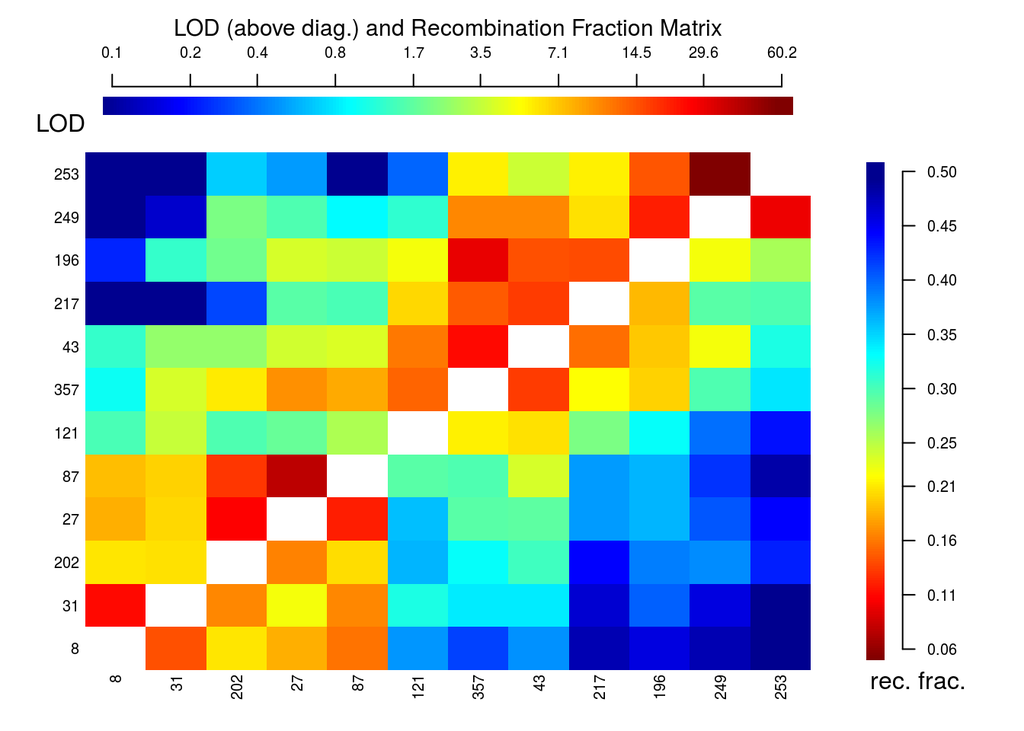

```r
comp <- LGs_1[[1]]$seq.num %in% mapa1[[1]]$seq.num
pos <- which(comp == FALSE)
trash2 <- LGs_1[[1]]$seq.num[pos]

Exten.LG_1 <- try_seq(mapa2[[1]], 357)

Exten.LG_1

pos <- Exten.LG_1$LOD == 0

pos <- which(pos == TRUE)

Check <- make_seq(Exten.LG_1, pos)

mapa2[[1]]
Check

rf_graph_table(Check, scale = 1.5,
               inter = FALSE, axis.cex = 0.75)
```

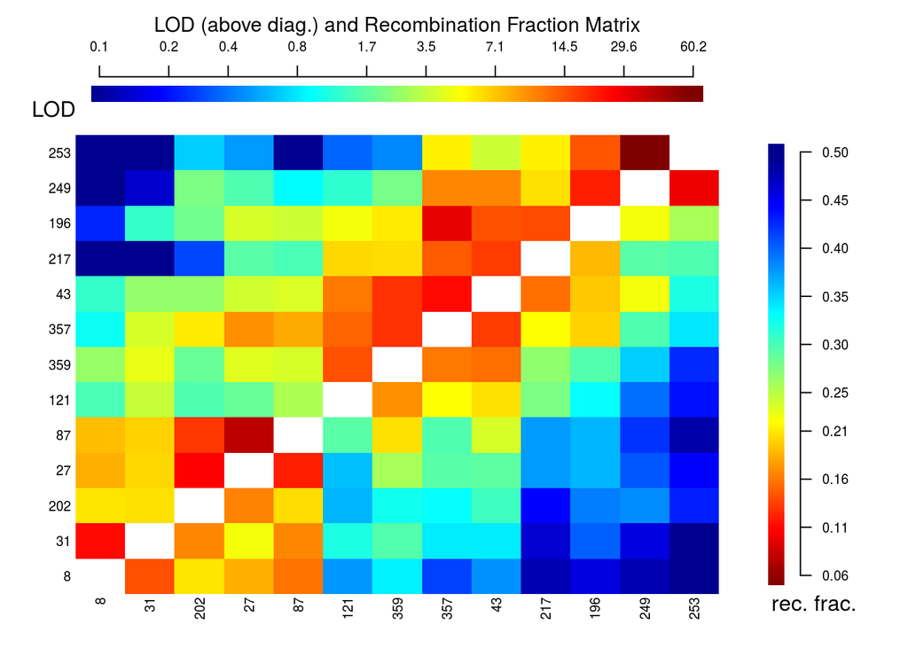

```r
LG1_1.exp <- make_seq(Exten.LG_1, pos)

#########

Exten.LG_1 <- try_seq(LG1_1.exp, 359)

Exten.LG_1

pos <- Exten.LG_1$LOD == 0

pos <- which(pos == TRUE)

Check <- make_seq(Exten.LG_1, pos)

LG1_1.exp
Check

rf_graph_table(Check, scale = 1.5,
               inter = FALSE, axis.cex = 0.75)
```

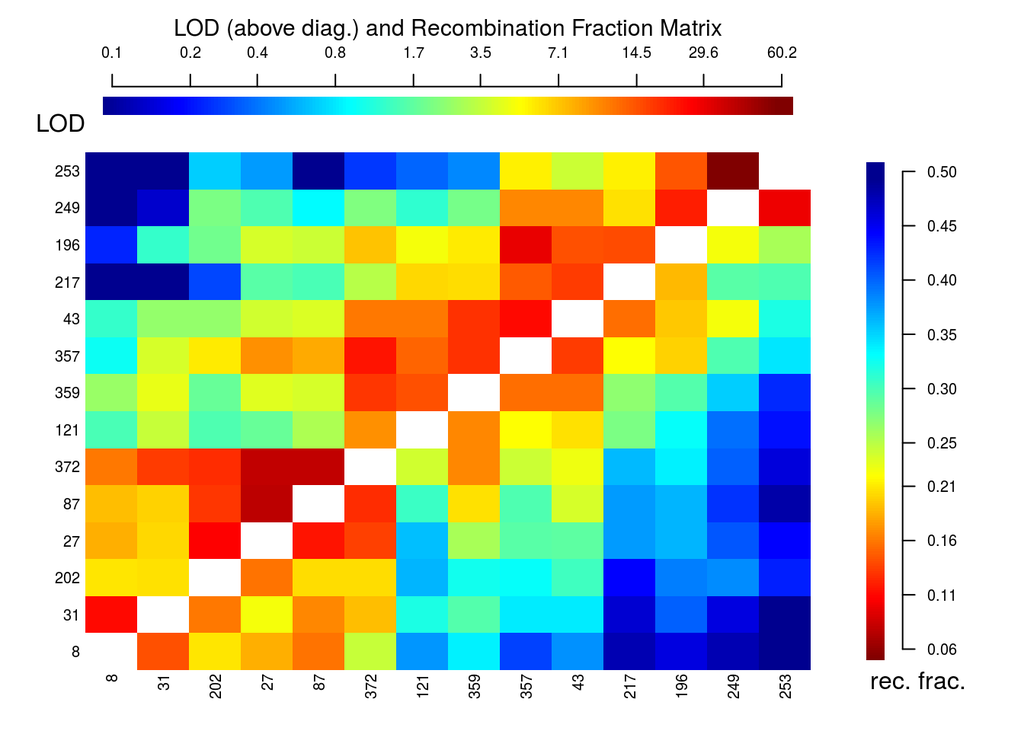

```r
LG1_1.exp <- make_seq(Exten.LG_1, pos)

#########################


Exten.LG_1 <- try_seq(LG1_1.exp, 372)

Exten.LG_1

pos <- Exten.LG_1$LOD == 0

pos <- which(pos == TRUE)

Check <- make_seq(Exten.LG_1, pos)

LG1_1.exp
Check

rf_graph_table(Check, scale = 1.5,
               inter = FALSE, axis.cex = 0.75)
```

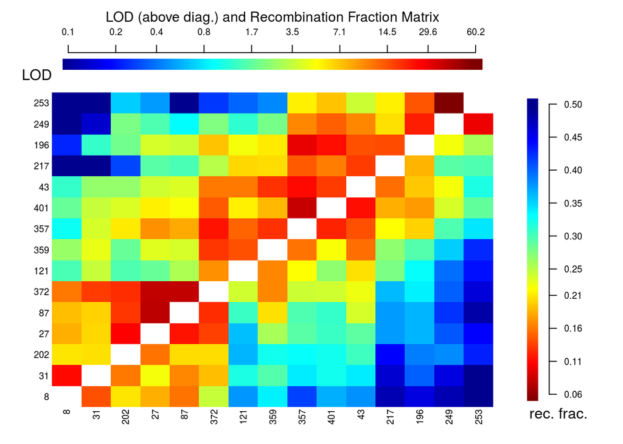

```r
LG1_1.exp <- make_seq(Exten.LG_1, pos)

#########################

Exten.LG_1 <- try_seq(LG1_1.exp, 401)

Exten.LG_1

pos <- Exten.LG_1$LOD == 0

pos <- which(pos == TRUE)

Check <- make_seq(Exten.LG_1, pos)

LG1_1.exp
Check

rf_graph_table(Check, scale = 1.5,
               inter = FALSE, axis.cex = 0.75)
```

```r
LG1_1.exp <- make_seq(Exten.LG_1, pos)
```

### 7.1.2 Removendo marcadores duvidosos

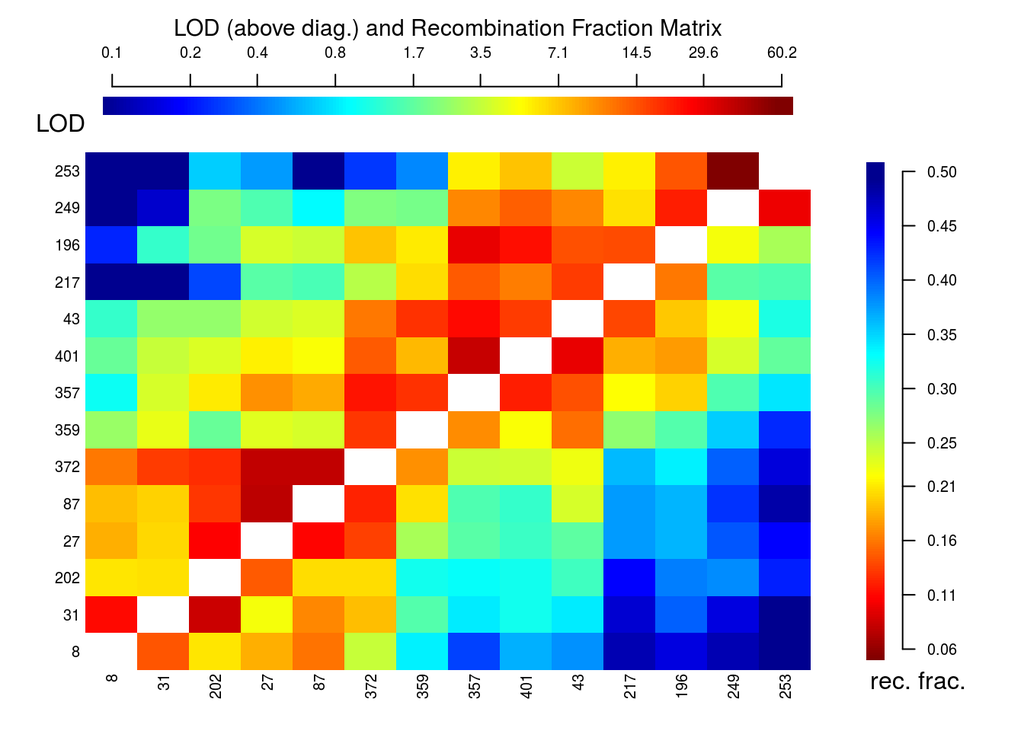

```r
Temp <- c(121)

Exc <- LG1_1.exp$seq.num %in% Temp

pos <- which(Exc == TRUE)

LG1.Exc <- LG1_1.exp$seq.num[-pos]

LG1_1 <- make_seq(rf2points1, LG1.Exc)

LG1_1

LG1_1.ord <- order_seq(LG1_1, n.init = 5, THRES = 3,
                     touchdown = TRUE, draw.try = FALSE)


LG1_1.ord.seq <- make_seq(LG1_1.ord, "force")

rf_graph_table(LG1_1.ord.seq, scale = 1.5,
               inter = FALSE, axis.cex = 0.75)
```

### 7.1.3 Inserindo novamente os marcadores

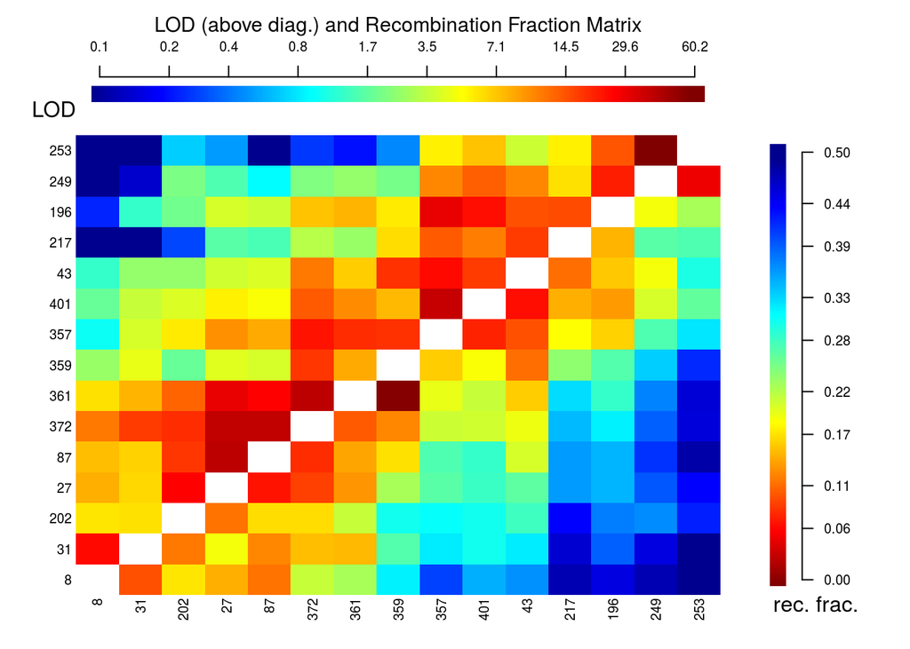

```r
Exten.LG_1 <- try_seq(LG1_1.ord.seq, 361)

Exten.LG_1

pos <- Exten.LG_1$LOD == 0

pos <- which(pos == TRUE)

Check <- make_seq(Exten.LG_1, pos)

LG1_1.ord.seq
Check

rf_graph_table(Check, scale = 1.5,
               inter = FALSE, axis.cex = 0.75)
```

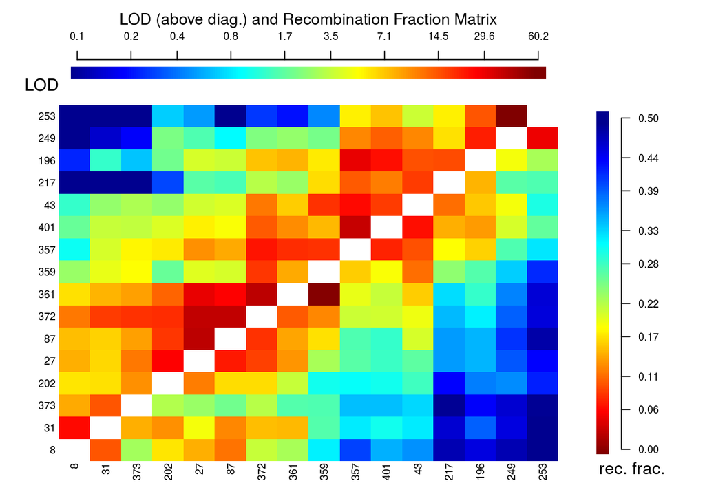

```r
LG1_1.exp <- make_seq(Exten.LG_1, pos)

#########################

Exten.LG_1 <- try_seq(LG1_1.exp, 373)

Exten.LG_1

pos <- Exten.LG_1$LOD == 0

pos <- which(pos == TRUE)

Check <- make_seq(Exten.LG_1, pos)

LG1_1.exp
Check

rf_graph_table(Check, scale = 1.5,
               inter = FALSE, axis.cex = 0.75)
```

```r
LG1_1.exp <- make_seq(Exten.LG_1, pos)

save(LG1_1.exp, file = "LG1_trash3.Rdata")
```

## 7.2 LG2

```r
comp <- LGs_1[[2]]$seq.num %in% mapa1[[2]]$seq.num
pos <- which(comp == FALSE)
trash2 <- LGs_1[[2]]$seq.num[pos]
trash2
```

```
## numeric(0)
```

```r
mapa2[[2]]
```

```
##
## Printing map:
##
## Markers               Position
##
##   2 AA420                 0.00
## 219 CC130                10.33
##  81 CA228                11.95
## 258 MgSTS316             19.02
##  36 BA301                49.93
## 186 BC167                59.95
##  41 BA172                67.64
##  99 CB280                69.47
## 264 MgSTS49              74.82
## 274 MgSTS106             75.72
## 297 MgSTS457             80.34
## 128 BD175                84.66
## 276 MgSTS56              89.32
## 317 MgSTS589             90.06
## 299 MgSTS513            102.72
## 331 MgSTS565            104.32
## 218 CC132               110.10
## 134 BD99                116.71
## 189 BC126               116.72
##  77 CA279               145.88
##
##  20 markers            log-likelihood: -1844.506
```

```r
mapa1[[2]]
```

```
##
## Printing map:
##
## Markers               Position
##
##   2 AA420                 0.00
## 219 CC130                10.17
##  81 CA228                10.38
## 258 MgSTS316             17.84
##  36 BA301                51.03
## 186 BC167                61.35
##  41 BA172                69.30
##  99 CB280                69.51
## 264 MgSTS49              75.55
## 274 MgSTS106             76.46
## 297 MgSTS457             81.07
## 128 BD175                85.73
## 276 MgSTS56              90.23
## 317 MgSTS589             90.94
## 299 MgSTS513            103.51
## 331 MgSTS565            105.09
## 218 CC132               110.98
## 134 BD99                117.64
## 189 BC126               117.81
##  77 CA279               147.96
##
##  20 markers            log-likelihood: -1845.185
```

```r
LG2_1.exp <- mapa2[[2]]

save(LG2_1.exp, file = "LG2_trash3.Rdata")
```

No grupo 2 não foram adicionados marcadores com desvios na segregação

Pequeno detalhe: houve alteração no tamanho e na verossimilhança do mapa, provavelmente devido ao maior número de marcadores no data.

## 7.3 LG3

### 7.3.1 Inserindo os marcadores

```r
comp <- LGs_1[[3]]$seq.num %in% mapa1[[3]]$seq.num
pos <- which(comp == FALSE)
trash2 <- LGs_1[[3]]$seq.num[pos]
trash2
```

```
## [1] 414
```

```r
LG3_1.exp <- mapa2[[3]]

save(LG3_1.exp, file = "LG3_trash3.Rdata")
```

Não foram adicionados marcadores com desvio neste grupo.

## 7.4 LG4

### 7.4.1 Inserindo marcadores

```r
comp <- LGs_1[[4]]$seq.num %in% mapa1[[4]]$seq.num
pos <- which(comp == FALSE)
trash2 <- LGs_1[[4]]$seq.num[pos]
trash2
```

```
## [1] 377
```

```r
LG4_trash3 <- mapa2[[4]]

save(LG4_trash3, file = "LG4_trash3.Rdata")
```

## 7.5 LG5

### 7.5.1 Inserindo marcadores

```r
comp <- LGs_1[[5]]$seq.num %in% mapa1[[5]]$seq.num
pos <- which(comp == FALSE)
trash2 <- LGs_1[[5]]$seq.num[pos]
trash2
```

```
## [1] 365 366 369 371 381 394
```

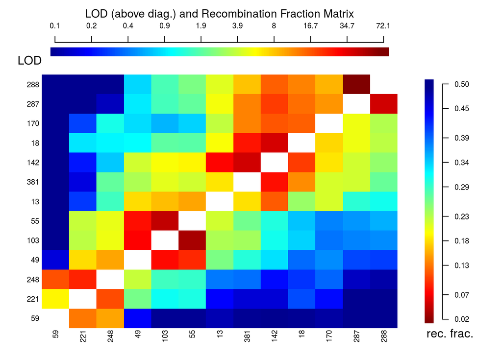

```r
Exten.LG_5 <- try_seq(mapa2[[5]], 381)

Exten.LG_5

pos <- Exten.LG_5$LOD == 0

pos <- which(pos == TRUE)

Check <- make_seq(Exten.LG_5, pos)

mapa2[[5]]
Check

rf_graph_table(Check, scale = 1.5,
               inter = FALSE, axis.cex = 0.75)
```

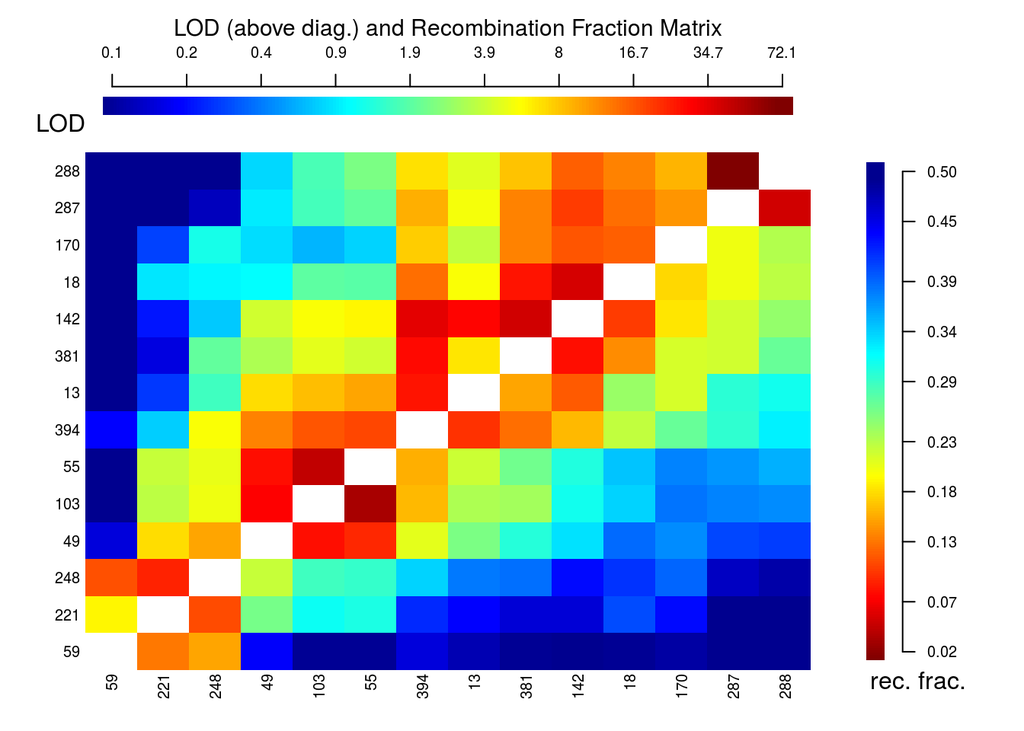

```r
LG5_1.exp <- make_seq(Exten.LG_5, pos)

#######

Exten.LG_5 <- try_seq(LG5_1.exp, 394)

Exten.LG_5

pos <- Exten.LG_5$LOD == 0

pos <- which(pos == TRUE)

Check <- make_seq(Exten.LG_5, pos)

LG5_1.exp
Check

rf_graph_table(Check, scale = 1.5,
               inter = FALSE, axis.cex = 0.75)
```

```r
LG5_1.exp <- make_seq(Exten.LG_5, pos)


save(LG5_1.exp, file = "LG5_trash3.Rdata")
```

## 7.6 LG6

```r
comp <- LGs_1[[6]]$seq.num %in% mapa1[[6]]$seq.num
pos <- which(comp == FALSE)
trash2 <- LGs_1[[6]]$seq.num[pos]
trash2
```

```
## integer(0)
```

```r
LG6_1.exp <- mapa2[[6]]

save(LG6_1.exp, file = "LG6_trash3.Rdata")
```

## 7.7 LG7

```r
comp <- LGs_1[[7]]$seq.num %in% mapa1[[7]]$seq.num
pos <- which(comp == FALSE)
trash2 <- LGs_1[[7]]$seq.num[pos]
trash2
```

```
## numeric(0)
```

```r
LG7_1.exp <- mapa2[[7]]

save(LG7_1.exp, file = "LG7_trash3.Rdata")
```

## 7.8 LG8

```r
comp <- LGs_1[[8]]$seq.num %in% mapa1[[8]]$seq.num
pos <- which(comp == FALSE)
trash2 <- LGs_1[[8]]$seq.num[pos]
trash2
```

```
## integer(0)
```

```r
LG8_1.exp <- mapa2[[8]]

save(LG8_1.exp, file = "LG8_trash3.Rdata")
```

## 7.9 LG9

```r
comp <- LGs_1[[9]]$seq.num %in% mapa1[[9]]$seq.num
pos <- which(comp == FALSE)
trash2 <- LGs_1[[9]]$seq.num[pos]
trash2
```

```
## numeric(0)
```

```r
LG9_1.exp <- mapa2[[9]]

save(LG9_1.exp, file = "LG9_trash3.Rdata")
```

## 7.10 LG10

```r
comp <- LGs_1[[10]]$seq.num %in% mapa1[[10]]$seq.num
pos <- which(comp == FALSE)
trash2 <- LGs_1[[10]]$seq.num[pos]
trash2
```

```
## [1] 395 399 415
```

### 7.10.1 Inserindo marcadores

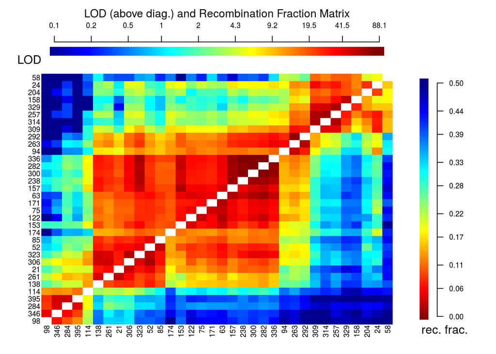

```r
Exten.LG_10 <- try_seq(mapa2[[10]], 395)

Exten.LG_10

pos <- Exten.LG_10$LOD == 0

pos <- which(pos == TRUE)

Check <- make_seq(Exten.LG_10, pos)

mapa2[[10]]
Check

rf_graph_table(Check, scale = 1.5,
               inter = FALSE, axis.cex = 0.75)
```

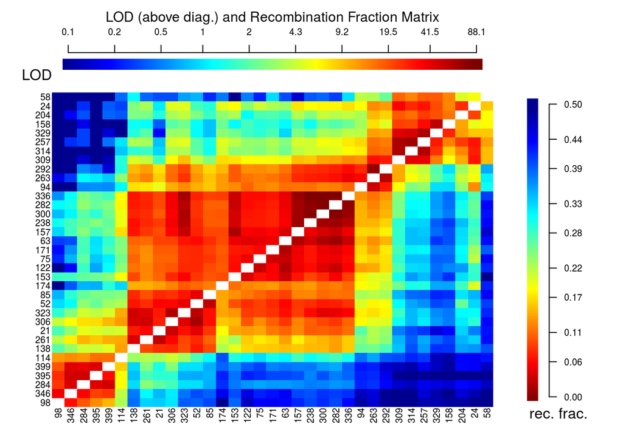

```r
LG10_1.exp <- make_seq(Exten.LG_10, pos)

######

Exten.LG_10 <- try_seq(LG10_1.exp, 399)

Exten.LG_10

pos <- Exten.LG_10$LOD == 0

pos <- which(pos == TRUE)

Check <- make_seq(Exten.LG_10, pos)

LG10_1.exp
Check

rf_graph_table(Check, scale = 1.5,
               inter = FALSE, axis.cex = 0.75)
```

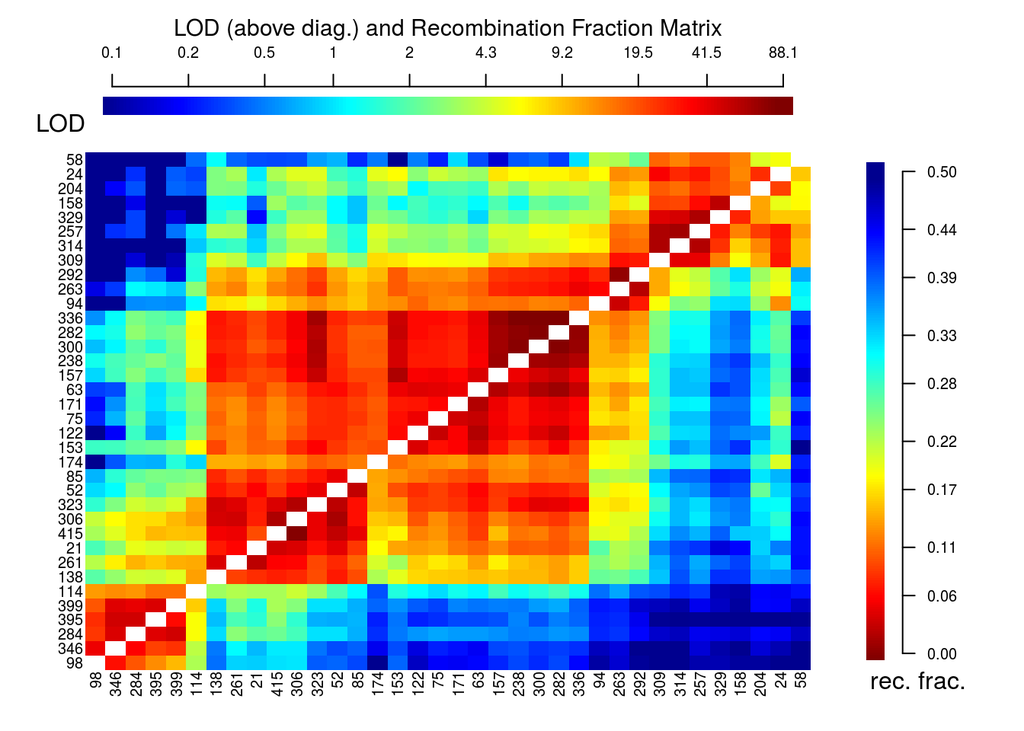

```r
LG10_1.exp <- make_seq(Exten.LG_10, pos)

#######

Exten.LG_10 <- try_seq(LG10_1.exp, 415)

Exten.LG_10

pos <- Exten.LG_10$LOD == 0

pos <- which(pos == TRUE)

Check <- make_seq(Exten.LG_10, pos)

LG10_1.exp
Check

rf_graph_table(Check, scale = 1.5,
               inter = FALSE, axis.cex = 0.75)
```

```r
LG10_1.exp <- make_seq(Exten.LG_10, pos)

save(LG10_1.exp, file = "LG10_trash3.Rdata")
```

Os três marcadores com desvio na segregação que agruparam com o LG10 foram inseridos no mapa

## 7.11 LG11

```r
comp <- LGs_1[[11]]$seq.num %in% mapa1[[11]]$seq.num
pos <- which(comp == FALSE)
trash2 <- LGs_1[[11]]$seq.num[pos]
trash2
```

```
##  [1] 358 360 363 367 370 380 383 385 386 390 391 392 393 398 403 404 407
## [18] 412 418
```

### 7.11.1 Reordenamento com `order_seq`

Como o grupo 11 é um grupo pequeno e foram muitos marcadores com desvios a serem inseridos, resolvemos ordenar exaustivamente com `order_seq`.

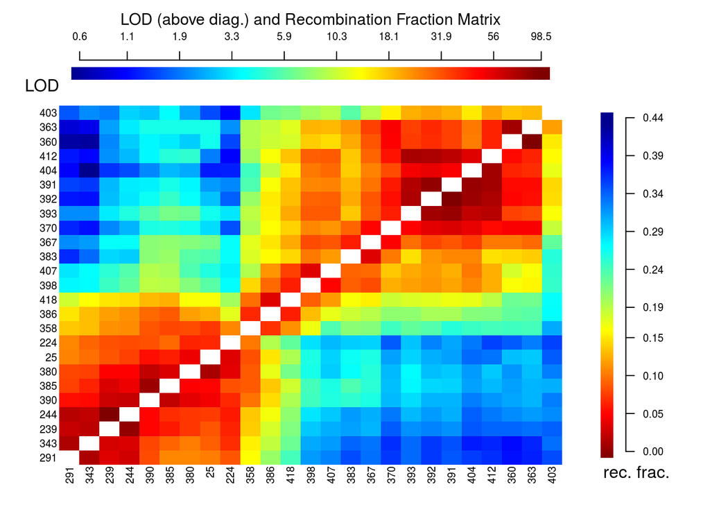

```r
order.LG11_1 <- order_seq(LGs_1[[11]])

seq_LG11_1 <- make_seq(order.LG11_1, "force")

rf_graph_table(seq_LG11_1, scale = 1.5,
               inter = FALSE, axis.cex = 0.75)
```

```r
LG11_1.exp <- seq_LG11_1

save(LG11_1.exp, file = "LG11_trash3.Rdata")
```

## 7.12 LG12

```r
comp <- LGs_1[[12]]$seq.num %in% mapa1[[12]]$seq.num
pos <- which(comp == FALSE)
trash2 <- LGs_1[[12]]$seq.num[pos]
trash2
```

```
## [1] 368 375 378 379 413
```

### 7.12.1 Inserindo marcadores

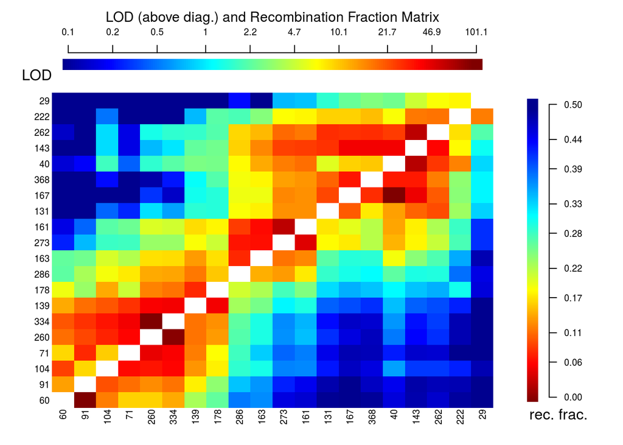

```r
Exten.LG_12 <- try_seq(mapa2[[12]], 368)

Exten.LG_12

pos <- Exten.LG_12$LOD == 0

pos <- which(pos == TRUE)

Check <- make_seq(Exten.LG_12, pos)

mapa2[[12]]
Check

rf_graph_table(Check, scale = 1.5,
               inter = FALSE, axis.cex = 0.75)
```

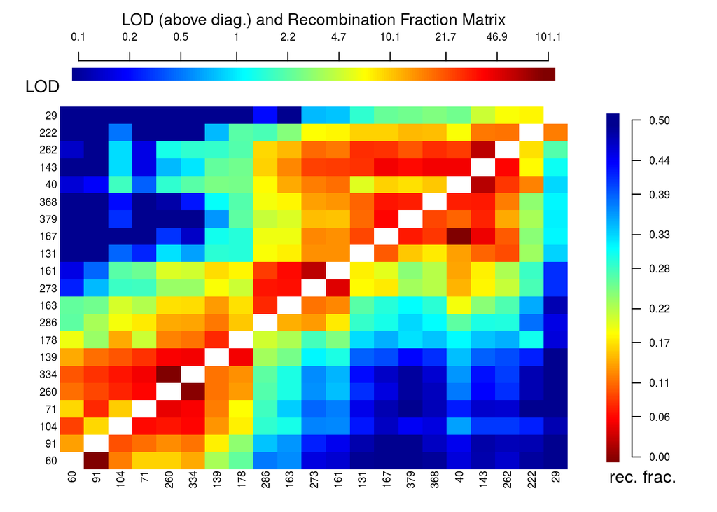

```r
LG12_1.exp <- make_seq(Exten.LG_12, pos)

######

Exten.LG_12 <- try_seq(LG12_1.exp, 379)

Exten.LG_12

pos <- Exten.LG_12$LOD == 0

pos <- which(pos == TRUE)

Check <- make_seq(Exten.LG_12, pos)

LG12_1.exp
Check

rf_graph_table(Check, scale = 1.5,
               inter = FALSE, axis.cex = 0.75)
```

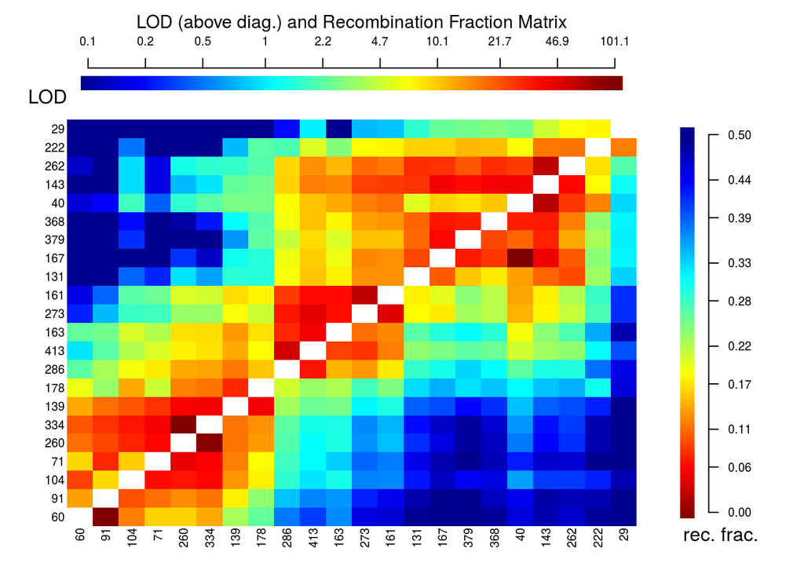

```r
LG12_1.exp <- make_seq(Exten.LG_12, pos)

#######

Exten.LG_12 <- try_seq(LG12_1.exp, 413)

Exten.LG_12

pos <- Exten.LG_12$LOD == 0

pos <- which(pos == TRUE)

Check <- make_seq(Exten.LG_12, pos)

LG12_1.exp
Check

rf_graph_table(Check, scale = 1.5,
               inter = FALSE, axis.cex = 0.75)
```

```r
LG12_1.exp <- make_seq(Exten.LG_12, pos)
```

### 7.12.2 Removendo marcadores duvidosos

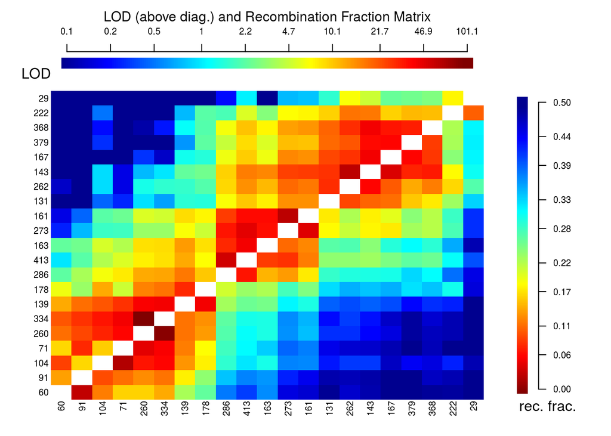

```r
Temp <- c(40)

Exc <- LG12_1.exp$seq.num %in% Temp

pos <- which(Exc == TRUE)

LG12.Exc <- LG12_1.exp$seq.num[-pos]

LG12 <- make_seq(rf2points1, LG12.Exc)

LG12

LG12.ord <- order_seq(LG12, n.init = 5, THRES = 3,
                     touchdown = TRUE, draw.try = FALSE)


LG12.ord.seq <- make_seq(LG12.ord, "force")

rf_graph_table(LG12.ord.seq, scale = 1.5,
               inter = FALSE, axis.cex = 0.75)
```

```r
LG12_1.exp
LG12.ord.seq

save(LG12.ord.seq, file = "LG12_trash3.Rdata")
```

## 7.13 LG13

```r
comp <- LGs_1[[13]]$seq.num %in% mapa1[[13]]$seq.num
pos <- which(comp == FALSE)
trash2 <- LGs_1[[13]]$seq.num[pos]
trash2
```

```
## integer(0)
```

```r
LG13.exp <- mapa2[[13]]

save(LG13.exp, file = "LG13_trash3.Rdata")
```

## 7.14 LG14

```r
comp <- LGs_1[[14]]$seq.num %in% mapa1[[14]]$seq.num
pos <- which(comp == FALSE)
trash2 <- LGs_1[[14]]$seq.num[pos]
trash2
```

```
##  [1] 364 376 382 384 387 388 389 396 397 400 402 405 406 408 409 410 411
## [18] 416 417
```

### 7.14.1 Reordenando com `order_seq`

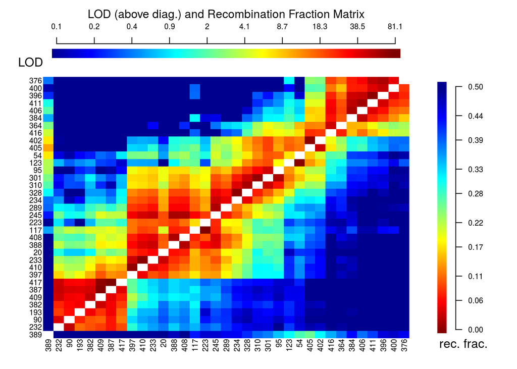

```r
order.LG14_1 <- order_seq(LGs_1[[14]])

seq_LG14_1 <- make_seq(order.LG14_1, "force")

rf_graph_table(seq_LG14_1, scale = 1.5,
               inter = FALSE, axis.cex = 0.75)
```

### 7.14.2 Removendo marcadores duvidosos

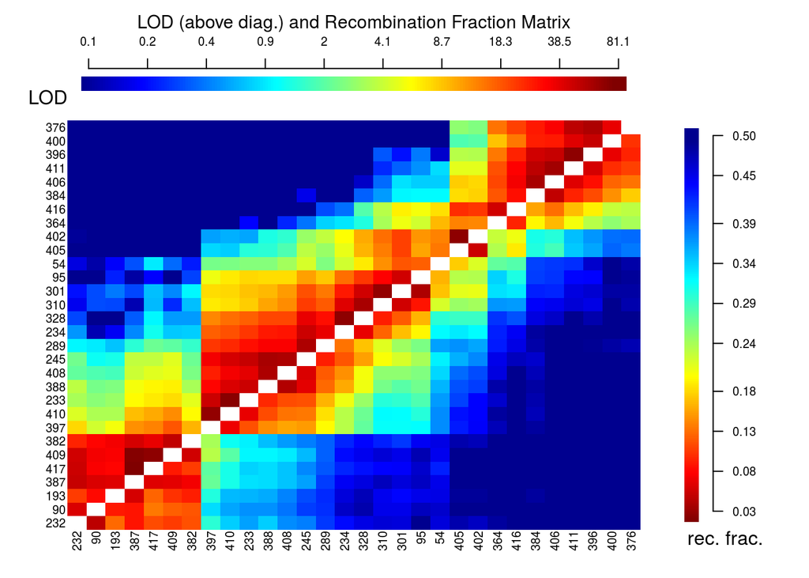

```r
Temp <- c(389, 20, 117, 123, 223)

Exc <- seq_LG14_1$seq.num %in% Temp

pos <- which(Exc == TRUE)

LG14.Exc <- seq_LG14_1$seq.num[-pos]

LG14 <- make_seq(rf2points1, LG14.Exc)

LG14

LG14.ord <- order_seq(LG14, n.init = 5, THRES = 3,
                      touchdown = TRUE, draw.try = FALSE)


LG14.ord.seq <- make_seq(LG14.ord, "force")

rf_graph_table(LG14.ord.seq, scale = 1.5,
               inter = FALSE, axis.cex = 0.75)
```

```r
LG14_1.exp <- LG14.ord.seq

save(LG14_1.exp, file = "LG14_trash3.Rdata")
```

# 8 Novo mapa

```r
mapa <- list()
load(file = "LG1_trash3.Rdata")
mapa[[1]] <- LG1_1.exp

load(file = "LG2_trash3.Rdata")
mapa[[2]] <- LG2_1.exp

load(file = "LG3_trash3.Rdata")
mapa[[3]] <- LG3_1.exp

load(file = "LG4_trash3.Rdata")
mapa[[4]] <- LG4_trash3

load(file = "LG5_trash3.Rdata")
mapa[[5]] <- LG5_1.exp

load(file = "LG6_trash3.Rdata")
mapa[[6]] <- LG6_1.exp

load(file = "LG7_trash3.Rdata")
mapa[[7]] <- LG7_1.exp

load(file = "LG8_trash3.Rdata")
mapa[[8]] <- LG8_1.exp

load(file = "LG9_trash3.Rdata")
mapa[[9]] <- LG9_1.exp

load(file = "LG10_trash3.Rdata")
mapa[[10]] <- LG10_1.exp

load(file = "LG11_trash3.Rdata")
mapa[[11]] <- LG11_1.exp

load(file = "LG12_trash3.Rdata")
mapa[[12]] <- LG12.ord.seq

load(file = "LG13_trash3.Rdata")
mapa[[13]] <- LG13.exp

load(file = "LG14_trash3.Rdata")
mapa[[14]] <- LG14.trash1

save(mapa, file = "mapa.Rdata")
```

# 9 Função Kosambi para obter distância em cM

```r
cM <- list()
for (i in 1:14){
  cM[[i]] <- kosambi(mapa[[i]]$seq.rf)
}
```

# 10 Preparando arquivo para desenho do mapa no MapChart

```r
map_chart <- data.frame()
for (i in 1:14){
  map_chart_names <- c(paste("GROUP",i), colnames(data$geno)[mapa[[i]]$seq.num])
  map_chart_dist <- cbind(map_chart_names, c("", 0, round(cM[[i]],3)))
  map_chart <- rbind(map_chart, map_chart_dist)
}

write.table(map_chart, file = "mapchart_file.txt", sep= "\t", quote = FALSE, row.names = FALSE, col.names = FALSE)
```

# 11 Total de marcadores no mapa

```r
tot <- vector()
for(i in 1:14)
tot <- c(tot, mapa[[i]]$seq.num)

length(tot)
```

```
## [1] 332
```